# À la recherche du travail perdu : une aventure commune

jul

25 mai 2025  
*Version: mai2025*  
Licence Anti Gad Elmaleh : Fais ce que tu veux avec ce livre sauf dire que tu l’as écris

# Pourquoi pas ?

Jusqu’à présent, j’ai toujours vu la recherche d’emploi comme une période démoralisante « où tu fais ta pute ».

Tu vas voir quelqu’un qui va faire un bénéfice net sur ton cul, et son but et que tu lui coûtes moins cher que tu lui rapportes … sauf quand t’es une rock star, un super employé que l’on trouve en haut de la pyramide des budgets de l’entreprise où tu décides des enveloppes et bizarrement aussi de la tienne.

C’est de bonne guerre ; si tu étais si finaud, t’avais qu’à faire un MBA avant tes 40 ans, hériter à 50, et monter ta boîte.

Voilà, c’est pas compliqué, il suffit de travailler dur pour y arriver. Pour les autres, « y’a qu’à traverser la rue ». Moi, je traverse la rue en regardant à droite et à gauche avant de traverser. Et c’est ce que je vais vous conter. Pourquoi ? Parce que la recherche d’emploi, j’ai décidé que ce serait fun cette fois.

Manque de pot, les emplois que je vise sont « des centres de coûts ». Dans une entreprise tu as le muscle : celui qui va faire du porte à porte pour vendre ton produit, et la graisse : l’humain qu’on aimerait bien remplacer qui coûte de manière récurrente en masse salariale sans que l’on puisse estimer combien il rapporte. C’est la production et les opérations.

# Plantons le décor

## Pourquoi pas administrateur système ?

Exemple : un sysadmin qui au vu des offres actuelles vaut 50 000€/an brut n’a pas de valeurs quand il fait bien son boulot, car quand il fait bien son boulot tout marche « sans problèmes ». Pour estimer ta valeur, il est bien que l’entreprise ait une idée du coût de combien ça coûte quand ça foire.

Genre, ton serveur de commandes de produit tombe alors tes pertes en nouvelles commandes sont linéaires avec le temps (modulo la saisonnalité du business).

Et le mieux, c’est tu es un accident X jours par an (du point de vue du sysadmin) car ton patron peut lier ta valeur à combien ça coûte quand ça marche pas.

C’est ce que fait la profession (pas planter la prod, hein), elle estime ainsi sa valeur et en dérive deux valeurs essentiels qui sont l’alpha et l’oméga de la valeur du sysadmin : la SLA et la GTR.

La SLA c’est l’acronyme anglais pour disponibilité (Service Level Agreement) : combien une entreprise tolère de pouvoir avoir ses serveurs arrêtés volontairement ou non par an.

Il est à noter que par exemple pour faire tester des plans de reprises d’activités ou pour maintenance on peut volontairement vouloir arrêter ses serveurs.

La SLA magique visée dans le milieu est 99.999%. 0.1% d’indisponibilité c’est 4h.

La GTR c’est la Garantie de Temps de Rétablissement dans le cas le pire quand il y a une couille. Disons que si t’as GTR est de 4h, avec un incident par an sur un truc central, tu es déjà en SLA de 99.9%.

Alors je crois pas en la magie, quand on m’annonce ce niveau de disponibilité visé et que je postule pour une offre de sysadmin : je fuis sauf si le patron s’appelle google et a la caillasse à la hauteur de ses ambitions. Oui, ce niveau magique est atteignable, mais comme j’ai appris en science expérimentale, tout est possible, ça dépend juste de ton budget.

Vous voyez google est un spécialiste de l’infra distribuée, redondante. La plupart des entreprises aimeraient viser la place de google, mais ils ne sont pas prêts à développer leur propre hardware, système d’exploitation, protocole de routage réseau logiciels … vu qu’ils ont déjà des cactus dans les poches à embaucher du sysadmin. Je veux dire quand tu connais les salaires des googleurs, tu pleures ; on ne joue pas dans la même catégorie.

D’ailleurs, si (je ne citerais pas de noms) certains avaient un syndrome de l’imposteur avant d’entrer dans ce genre de boîte, un salaire à 6 chiffres le soigne vite et bien.

Donc, comme aucun sysadmin honnête qui a déjà eu à faire à des fournisseurs business notamment les telcos [^1] avec des GTR souvent de 4h heures ouvrées [^2] tu peux difficilement espérer dans le cas le pire qui pourrait impliquer un incident réseau opérateur une GTR inférieure à 4h.

Et encore, si tu veux une SLA de 99.9% avec ta GTR de 4h, il faut prendre en compte le temps de diagnostic nécessaire à mettre le nez dans le caca au BON fournisseur. En général, ça prend pas une demi heure. Donc, la SLA avec un truc centralisé qui a une panne réseau, en général c’est pas une solution d’avenir.

Le rôle d’un sysadmin n’est pas tant de s’assurer qu’il y ait pas de problèmes que de s’assurer que les problèmes ne se voient pas. En général, ça nécessite une infrastructure redondante, qui tel un avion moderne bi moteur est capable d’assurer 100% du service sur une partie des infras en attendant que la partie en panne soit rétablie pendant la période critique où les infras sont en mode dégradée.

C’est devenu une spécialisation à part entière du métier de sysadmin qui est SRE engineer (ingénieur de fiabilité des services). Ça pète moins en le disant en français c’est pour ça qu’on utilise l’acronyme anglais.

Bref, admin sys c’est un métier sympa de prod où les astreintes, les réponses sur incidents en urgence, les plans de reprise d’activité font partie de ton épée de Damoclès quotidienne.

La bonne façon de le gérer, c’est de se préparer au pire et de s’organiser AVANT les incidents pour répondre aux incidents. Voir même, parfois de faire des tests grandeurs natures pour vérifier qu’une solution miracle sensée améliorer cette fameuse SLA fort coûteuse et complexe tient bien ses promesses à petites échelles (temporelle et locale) avant d’être déployée. Tenir un laboratoire et y faire des déploiements de nouveaux services en faire la qualification et le recettage (de la mise en chantier quoi), fait aussi parti du métier.

C’est un métier, plus que développeur, où la sécurité informatique est prise au sérieux, notamment sa culture. En sysadmin, le ticket d’intervention est l’équivalent du commit du codeur.

Il est important de laisser des traces de ce que l’on fait et de les terminer à la fin de chaque jour ouvré, des fois que l’incident soit soi même qui se mange un bus en allant au travail le lendemain matin.

Pourquoi ? Parce qu’une infra au contraire du code est un objet fondamentalement mutable. Et qu’il faut pouvoir connaître l’état des mutations tant des infras que des opérations en cours et/ou récemment terminées.

Tiens le serveur de base de données est tombé à 16h00 ce vendredi, il y avait-il une intervention en cours ?

Et la culture sécurité n’est pas de documenter ses interventions pour blâmer le quidam, mais dans une culture « juste » pour corriger les erreurs. Par exemple si un quidam a commis une boulette sur un équipement où il était autorisé, la réponse logique RH[^3] consiste à lui proposer une formation si il est en manque de connaissance et peut être de modifier les processus RH

La sécurité c’est aussi de la paperasse. Je le dis d’une manière qui a l’air péjorative, mais de même que le codeur est structurés par des normes (IETF, 3GPP, unicode, ISO) qui évitent de réinventer la roue, le sysadmin lui est plus sensibilisé aux normes de « conformité ». Genre la ISO 27001 concernant la cybersécurité, ou la conformité RGPD concernant la protection et le recueil des données à caractère personnel.

On (rarement les sysadmins) identifie des risques, on identifie les coûts associés aux risques (genre fuite de données, interruption de services…) et le sysadmin se voit inclus dans la démarche de conformité. Ça peut être vu comme une lourdeur pour certains, car assez souvent les normes de conformité impliquent la traçabilité des actions et donc leurs documentations à la fois en amont (décrire comment tel ou tel problèmes est adressé) et au fil de l’eau : « faire ce que l’on dit, dire ce que l’on fait, et accepter d’être audité ». Ça peut avoir un coté inconfortable que tous n’acceptent pas de vivre « dans une maison de verre ». Moi, tant que l’entreprise respecte la culture « juste » sécurité (la même qu’en aviation), ça me va.

C’est un super métier.

## Pourquoi pas développeur python ?

J’ai déjà décrit dans [Loser du libre](https://jul.github.io/cv/yahi.html) un autre de mes livres libre ma vision du développement python en disant des choses très méchantes sur les entreprises quant à la livraison du code.

Grand père était maçon, malgré ses aventures que je découvre au détour des conversation avec les voisins, il était discret, et ne m’a transmis qu’une chose de sa culture : un bon ouvrier se reconnaît au fait que son établi est toujours propre. La propreté est au cœur de tout les métiers. Et l’informatique n’y coupe pas.

Par exemple, là où en tant que sysadmin j’accepte que mon travail soit en « cours de mutation » (genre un backup peut prendre 2 jours dans des circonstances spéciales), en informatique, j’aime que ma paillasse soit propre en permanence.

Même si je ne pousse pas mes modifs, je les découpe en tâches qui tiennent dans une journée et m’arrange pour que quand je quitte mon poste de travail, il n’y ait pas de « code en cours ». J’appelle tout ce qui a un début et une fin : un chantier, et ce que je commence et termine dans une journée un « micro chantier ». Et je pense important de garder l’autonomie sur les micros chantiers (jalons) qui permettent de garantir un avancement du chantier global sans mauvaises surprises par rapport notamment aux délais.

Dans la pratique du code, les allers retours avec les clients par le truchement des « tickets » si chers aux sysadmins, mais pas autant appréciés des développeurs se sont généralisées. Perso, ça me va, même si ça peut interrompre quand c’est mal géré un tunnel de concentration pour coder.

En effet, quand on code, il faut remonter le contexte en mémoire avec des tas de paramètres et variables et c’est comme jongler : un souffle de bruit, d’interruption et hop : tout tombe.

Donc, en général j’apprécie les entreprises qui permettent de planifier sa journée en discutant autour d’un café (le mieux) ou d’un scrum meeting (avec un café) avec l’équipe pour préparer sa journée.

Il y a aussi une tâche pas très folichône à réaliser quand on est dev et que je conseille de faire TOUS les jours c’est « l’imputation de budget ». En général, un développeur travaille rarement sur un produit ou pour un client exclusivement. Et ce parfois sur une journée (ce qui est pas glop).

Je vous ai déjà dit qu’un sysadmin aussi c’est un centre de coût ? Un dev aussi. Comparé à du hardware, le temps homme coûte un bras. Externalisé il coûte 350-1500€/jours internalisé, je peux En interne un dev coûte -*salaires différés[^4] compris*- bien moins qu’un externe. On considère que par exemple un Espace de Service Numérique (anciennement SSII, parfois appelés marchand de viande par les mauvais esprits) doit faire une culbute de x2.7 pour permettre aux non dévs de (bien) vivre. Hors on a une base de référence : les salaires minimum de la SYNTEC. À condition de travail égal (pas de personnes sous les ordres) on est sur la fiche de poste qui correspond à l’indice ~2.1 de la SYNTEC ce qui donne en prenant l’approximation suivante

- 24 jours travaillés par moi
- un salaire brut de 2500€/mois (coeff 2.1)

100€/jours auquel il faut ajouter les coûts des fonctions supports (RH, DAF, immobilier, …) soit 50% à la louche.

Si on applique un multiplicateur de rentabilité propre à la commercialisation/marketing/infra lié au centre de coût informaticien (on prendra celui des SSII de 2.7), le développeur/sysadmin doit rapporter 405€/jour à l’entreprise. Il est plutôt vendu 500€/jours.

Les freelances ont en plus leurs inter-contrats à supporter sur leurs finances personnelles. Ceci étant une fonction de la variable aléatoire on l’estimera à quelque chose entre 0 et 50% du temps.

Soit 25% (à comparer aux 10% de primes de précarité des CDD) à la louche (et je n’évoque pas les crédits à prendre pour les retards de factures, quand les factures sont réglées (c’est courant dans le monde des freelances)).

Ce qui nous fait un taux équivalent pour les freelance de 220€/jour. Et ça c’est pour un freelance qui n’a pas de démarchages commerciaux à entreprendre (réseautage), ni de frais (achat de consommable, matériel, comptables).

Dîtes vous que les tarifs journaliers des freelances sont calibrés au plus juste et qu’ils ne sont pas « bien » payés. *Been there, seen this*, le monde des freelance est rempli d’aléas qui ne se limite pas à la facturation, mais inclus aussi les années où les organismes vous réclament des sommes indues (genre à mon époque le RSI était fameux pour ça). Je ne soulignerais jamais assez que pour se lancer en freelance il faut avoir la trésorerie, même quand on est à 100% de jours travaillés pour tenir « une années blanche » (sans revenus) tout en en subvenant à ses besoins de travailleur.

Donc, si en tant que développeur vous voulez survivre longtemps, être sûr d’être imputé sur un « projet/budget » rentable n’est pas un truc dont il faut s’enquérir une fois en intégration chez le client. Je suggère quand vous êtes en entretien d’embauche de vous « intéresser » fortement aux projets sur lequel vous allez être non seulement techniquement, mais aussi en terme de viabilité à long terme. En général, le client/recruteur vous embauche pour un besoin spécifique, sur un projet.

Et dans la partie « mines », je développerais l’implication que ça a.

## Pourquoi pas devops ?

Face aux manque de fluidité d’avoir un métier résolument conservateur face à la prise de risque (les administrateurs systèmes) et un autre résolument en mode YOLO, on pète tout à chaque nouvelle version, le métier informatique a élaboré un espèce de métier hybride à l’interface entre les deux : le DevOPS.

C’est une méthodologie et un outillage qui diffère des deux métiers précédemment cités, mais sans apporter de disruption.

Le développeur est mis en contrôle d’un pipeline de production intégré qui lui permet idéalement d’avoir un espace de développement identique à la prod. Là où avant il y avait un passage de relais[^5] des produits finis par les dévs, testés … en recettage (parfois ignoré), puis une bascule en production de manière récurrente et programmées, on passe à une architecture en déploiement continu où les développeurs sont canalisés par les outils d’intégration continus à fournir test/recettage/validation systématiquement à chaque étape du développement.

En plus comme c’est bien fait les outils modernes, quand ça foire on a un bouton « rollback » (annuler) qui permet de revenir à l’état immuable précédent.

Ça demande un peu plus de compétences que simplement développeur, ou sysadmin car il faut s’intéresser à plus de parties traditionnellement dévolues à l’Assurance Qualité, l’administration système, et parfois même au support.

Dans ce contexte, le sysadmin est bien plus sollicité que dans une infrastructure classique quand il est internalisé, car les infrastructure devops sont bien moins stables que les infrastructures classiques en terme de publication de (base de données, serveurs web, équilibreurs de charges, DNS …) et cerise sur le gâteau devops il y a cette partie opaque qui est pour le moins plus compliquée qu’on appelle « le réseau défini par le logiciel » (Software Defined Networks) qui intègre non seulement le graph de connexion entre les services, mais aussi … tadam … la sécurisation des services.

Ce qui fait qu’en général, devops rime avec disparition des sysadmins hors -*et je m’enquiers du sujet car il est important*- DNS, gestion des identités (LDAP/AD/Oauth) et pour les domaines les plus critiques mails.

Pourquoi les mails me direz vous ?

Car de nos jours moults procédures de récupération de mots de passe passent par les emails. Et quand on est critique (nucléaire, défense, service public) c’est mieux de garder les services d’identifications directs et indirects proches et de pouvoir garantir leur intégrité. M’enfin, les gens vont ce qu’ils veulent.

Et pour le DNS, j’ai envie de sortir un proverbe sysadmin courant : *« It’s always DNS »*[^DNS]

Bref, devops c’est comme un développeur dont les infrastructures ont été pensé pour qu’il puisse déployer du logiciel « sans coutures ». J’entends par sans coutures qu’il n’y a pas besoin de faire une interruption programmée des infras pour dérouler le nouveau code et ça minimise en intégrant l’Assurance Qualité tout au long du processus les mauvaises surprises.

Moi, je trouve que c’est une chouette évolution du métier de développeur qui me convient :D

[^DNS] : c’est évidemment la faute du serveur de nom de domaine

## Pourquoi pas déménageur ?

Lol, le contrat journalier (donc tu refais ton entretien d’embauche tout les jours) payé 10€/h pour 7h30 théorique, 15h effectif à trimer comme un damné je ne dis pas que j’ai pas aimé, mais je dis que pour aller chercher ma fille à l’école c’est un peu tendax.

J’ai adoré être déménageur, c’était un autre monde, comme un voyage dans la société, avec des gens que j’ai pas mal aimé. Je me suis senti proche de mes collègues ; y’avait un vrai esprit d’équipe car on était tous à vouloir rentrer le plus tôt possible chez nous ; on était tous dans la même galère du patron abusif qui nous faisait enchaîner les chantiers au delà des heures alors que c’est pas la pratique.

Ça s’appelle la cohésion face à une menace réelle.

## Pourquoi pas autre chose ?

Pour moi, pour vous, être ouvert à autres choses, c’est une possibilité de découverte.

Le « voyage social » est aussi intéressant que le voyage tout court, moi je suis sur terre, et j’aime la vie, notamment car elle est capable de toujours nous montrer des choses nouvelles et je ne connais peu d’expériences qui soient désagréables.

# une routine saine pour une recherche saine

Primo, la recherche d’emploi n’est pas « un métier à temps plein », pour deux raisons :

- qui trop embrasse mal étreint ;
- la vaisselle va pas se laver toute seule.

Je vous conseille de lire mon livre sur [la vie palpitante d’homme au foyer](https://jul.github.io/cv/haf.book.html) sur le sujet :D

Oui écrire fais tu bien, ça permet d’objectiver ce que l’on fait, de le découper en rondelle et de bien le ranger dans le cerveau. Ça me permet de détourner des routines professionnelles obsessives en élan créatif. Lol.

## Contenir le temps

Pour ne pas devenir chèvre il est important de ne pas laisser le temps de recherche d’emploi mordre sur les autres temps et de rythmer ses activités. Pas au métronome certes, mais à la louche.

Genre, je dédie ma matinée : à envoyer les machines à laver (linge et vaisselle) pour préparer l’après recherche d’emploi puis à la recherche d’emploi elle même. Comme ça je me retrouve pas sous un monceau de tâches à rattraper après.

La recherche d’emploi est découpée en 3 phases :

- présent : l’écrémage et la sélection des offres en mode ; celui qui se lève le plus tôt répond le plus tôt,
- passé : relire le CV, l’améliorer, intégrer les retours, republier les CVs PARTOUT où ils sont présents,
- futur : écrire ce livre pour le fun, et planifier le retour à l’emploi (faire faire un peu plus de tâches à ma fille pour la sensibiliser au coût homme des tâches ménagères)

## Qui trop embrasse mal étreint

Vu que l’IA se développe, c’est plus que jamais le moment de chiader les lettres de motivations à la main. Ce qui veut dire que pour chaque offre d’emploi, vous avez intérêt à vous en souvenir et avec trop d’offres d’emplois vous allez oublier quelque chose qui était peut être votre petit plus.

En ce qui me concerne j’ai deux techniques pour réduire l’empreinte mémoire de chaque lettres de motivations :

- avoir toujours le même plan Vous (l’entreprise et ce qui m’intéresse chez elle), Moi, Nous (pourquoi nous sommes faits pour nous entendre)
- être sous mes vraies couleurs.

Ne pas mentir me permet de ne pas avoir à me souvenir de ce que j’ai raconté me concernant et mes aspirations.

Bon, je dis pas tout, comme par exemple que j’ai une cervicale qui me scie un nerf et que j’aimerais bien retrouver un boulot pour éviter de terminer paralysé d’un bras car je trouve que c’est un peu anxiogène, et puis surtout ça pourrait me couper d’un job de développeur/déménageur qui pourrait voir le jour.

Mais restons concentrés ; on ne peut pas humainement se souvenir de TROP d’interactions, je me suis fixé une limite de 2/3 offres par jour auxquelles répondre, et une fois les réponses faites, je passe à vérifier si il y a pas des sources d’offres d’emplois que j’aurais négligées. La monoculture informationnelle est un piège :D

## Intégrer l’IA dans sa recherche

Revenons à l’IA : elle a les défauts de ses qualités.

- elle est pédante, on croirait un prof d’université bien campé dans ses certitudes, hyper confiante ;
- elle est hyper verbeuse ;
- elle hallucine

Pour toutes ces raisons j’ai développé une routine d’écriture anti IA. Après tout, si il y a une fonction d’entreprise qu’elle menace de plein fouet dans sa capacité à « classifier » et « générer de la parlotte », c’est bien les ressources humaines.

J’ai testé le vibe coding (coder assisté par IA) et malheureusement pour l’IA elle s’est plantée : son point faible c’est le traitement du signal et l’acoustique. Je dis ça, mon pote ben a eu exactement les mêmes problèmes du fait que l’IA est à coté de la plaque dès qu’il s’agit d’intégrer le théorème de Shannon (sur échantillonage) ou celui de Nyquist (sous échantillonage).

Ça m’a fait plaisir de voir que d’une part mon temps sur les bancs de l’unif n’avait pas été en vain, et d’autre part que l’IA ne me menaçait pas directement tant que je sais où réside ma valeur : dans mon éducation scientifique.

C’est de cette expérience que j’en ai pondu mon [accordeur de guitare en python](https://gist.github.com/jul/ae03e76173c73265c9ed45f06ba2b1c3)

Donc ami RH, amie RHe, sache que je suis avec toi de tout mon cœur. Et voilà mes recettes pour tenter de concurrencer l’IA à l’écrit

- une petite phrase humoristique pour dire que c’est pas écrit par IA ;
- la concision avec mon plan en 3 parties bien explicite (Vous, Moi, Nous)
- la clarté avec un style plus relâché que d’habitude (moins pète sec, sans être familier)

Est-ce que ça marche ?

J’en sais rien, mais moi ça m’arrange, ça me permet de me distinguer de la concurrence.

## Rôder

Chaque réponse, chaque entretien est une occasion de s’apercevoir si le CV a été bien compris, en écoutant les questions posées en retour.

En ce qui me concerne une question est plutôt un échec : ça veut dire que quelque chose n’est pas clair. Et comme chaque item de mon CV est traité différemment je peux voir comme en A/B testing ceux qui ont plus de succès que les autres.

Vaut il mieux développer les expériences au risque d’avoir un CV de 5 pages ? Où comme je le faisais à une époque être suffisamment succint pour tenir sur 2 pages ?

La réponse vient de l’interaction la plus courante avec les recruteurs.

Je suis temporairement arrivé à la conclusion que les technos les plus récentes étant dans les expériences … récentes, ce sont celles à développer.

## Faire des activités extérieures

Cette concentration peut vous faire oublier le temps, mais l’heure d’amener et chercher ma fille à l’école, sortir le sac à puce, aller en biclou faire les courses au super marché moins cher à 5 km de là m’assurent une routine saine.

Finalement, la recherche d’emploi et être homme au foyer se combinent bien, l’une apportant la stimulation intellectuelle, et l’autre la routine rassurante qui évite de trop penser dans le vide dans l’attente des réponses.

En général, les recruteurs/ESN me rappellent dans la semaine, les employeurs directs mettent un peu plus de temps. Ça veut dire que si comme tout le monde vous privilégiez d’éviter LA mine actuelle du recrutement, il est préférable de rajouter un peu de lag (délai) dans vos réponses aux premiers.

# Tout n’est pas rose

## La charge mentale

Le rôle du RH est par sa fonction de vous amener à vous faire « dégonfler votre valeur » pour diminuer la masse salariale. La contre mesure logique est de faire la roue comme un paon.

Mais, moi, j’aspire juste à être moi même, ni au dessus, ni en deçà. Et le problème est que ça veut dire que soit je dois me mettre des plumes dans le cul, chose que je n’affectionne pas particulièrement, soit je dois partir en position de négociation tendue du slip ; j’ai pas envie de partir pour descendre la marge. Marge qui selon la convention syntec -celle du métier- interdit de payer moins qu’un certain montant au vu de mon expérience ~2400€/mois et des postes que je demande.

## Les salaires en informatique

Et c’est heureux. Croyez moi dans le métier connaître la grille SYNTEC par cœur avant d’aller parler rémunération est une bonne chose.

Quand on me propose le minimum pour une fiche de poste qui est largement au dessus des attentes des coefficients SYNTEC, je tique. C’est pas comme si cette convention était la mieux disante. C’est même une des moins protectrice des salariés de France. Je préférerais être en convention métallurgie par exemple (fondeur de microprocesseur).

Mais, je fais comme si ne connaissais pas la convention collective. Histoire de séparer ceux qui tentent de me rouler dans la farine et ceux qui sont honnêtes.

La rémunération se discute une fois la fiche de poste bien établie.

Prenez un dev senior qui a du métier dans le pattes et qui coache ses padawans. On est plus dans l’éxecution propre au 2.1 (pour ceuzes qui ont plus de 26 ans) (2400€) mais dans le coeff 2.3 selon la [classification des cadres SYNTEC](https://www.syntec.fr/wp-content/uploads/2019/11/annexe-2-classification-des-ingenieurs-et-cadres.pdf) et bizarrement le recruteur cherche aussi à vous embaucher en 2.1 pour vous vous faire du 2.3. Ce qui est pas gentil.

Mon conseil, surtout avec les intermédiaires est : « *évitez de vous négocier avec un montant global, conditionnez vos exigences salariaux à la fiche de poste* ».

## Le temps de travail

Un mythe du métier c’est que nos heures de travail ne sont pas comptés et qu’en échange on récupère 1.5 jours de congés par mois en échange.

La vérité est que la charge hebdomadaire est de 48h max (OIT), 12h max journalière (OIT) et donne le droit à des récupérations. Et que sinon, on est sur du 35h/semaine + 3.5 soit 38.5h par semaine.

Une habitude que j’ai apprise chez mes amis déménageurs et d’avoir un cahier où je note mes heures comme pour aller voir Michel mon patron déménageur et lui dire : *Kevin, les calculs sont pas bons*. Je veux bien trimer comme un damné quelques fois, mais ni tout le temps, ni sans récupération. Ouais, moi je suis comme ça, mon oseille, c’est du temps de vie. Mon contrat me lit à une enveloppe hebdo : et j’évite qu’elle se déséquilibre de semaine en semaine. Ni débiteur, ni créditeur.

Dans la vraie vie, j’ai souvent donné du 50/60h par semaine pendant les crunchs et ça m’a rippé le cerveau et la vie. Je pense que l’intro de [sherpa du code](https://raw.githubusercontent.com/jul/faire_un_livre/main/exemple/sherpa.pdf) est probablement l’expérience la plus traumatisante que j’ai eu suite à une série de surmenage. Écoutez, j’ai plus envie de tuer un ami. J’ai plus envie de manquer d’énergie pour tendre la main à un pote car le boulot m’a rincé, et ce n’est plus négociable maintenant que j’ai une famille.

Moi, je suis un homme de contrat, c’est dans ma culture protestante. Mais le contrat n’est plus en vogue.

## La nouvelle saloperie : le CDD déguisé en CDI

Ça c’est une nouvelle mode dont on cause pas en informatique qui est assez foireuse. C’est de faire miroiter une embauche définitive à un gadjo pour au final le jeter à la fin d’un projet.

Ma mentalité « ouvrière » ne voit pas de problème à être en CDD à commencer une tâche et la terminer. Mais, j’aime pas quand on tente d’abuser la vulnérabilité intrinsèque à être en recherche d’emploi.

Le CDD coûtant 10% plus cher que le CDI, c’est pas qu’une question de tune. C’est aussi une question de faire prendre des vessies pour des lanternes. Et croyez le ou pas, certains « recruteurs » adorent ça.

En général parmi les red flags (signes annonciateurs) il y a la combo : période d’essai (renouvelée chez le recruteur) puis chez le client final. Rajouter l’illégale « je suis désolé, on pratique la reconduction automatique » et vous avez les signes clairs que l’on vous embringue dans cette arnaque. Ça m’est arrivé récemment, comme à d’autres qui étaient prévenus, et c’est toujours rageant de se faire avoir, d’autant plus qu’en général ce sont souvent les boîtes qui vantent pendant leur processus de recrutement « *leur compagnie qui respectent l’humain* ».

Alors, je vous enjoint à avoir une preuve écrite que la reconduction est automatique, car ça ça passe direct à l’inspection du travail ou aux prud’hommes sans avoir besoin de passer par la case triturage de neurones juridiques.

Alors, à force d’être un routard de la recherche d’emploi, maintenant quand je vois une accroche dans les offres d’embauche, je me méfie et fais la contraposée logique et me dit que c’est peut être la réalité RH de l’entreprise. Finalement, la culture étant du formel qui s’ignore, le slogan décrit non la culture mais un pot de miel. Et la culture, c’est tout sauf ce qui est décrivable. Tiens tentez de décrire la culture d’un groupe auquel vous appartenez (genre sport ou loisir) en quelques mots, je vous mets au défi d’y arriver.

Tenez ; je fais de la boxe française j’ai envie de dire que notre culture c’est de se faire mal, et pourtant, le nombre de traumas par adhérents est inférieur à des sports de vrais brutes comme le foot. Bon, j’en viens à la conclusion que si on prend la contraposée : « c’est se faire du bien » on arrive à un truc plus proche de la réalité (CQFD).

# Improviser, s’adapter, surmonter

Oubliez le bullshit que j’ai dit sur une recherche saine dans une routine saine.

La vraie vie en a rien à foutre de vos intentions.

Ce matin, je devais emmener ma fille à l’hosto se faire retirer son plâtre, mais paf, cette nuit elle a eu une gastro, ma femme a besoin d’être aidée car sa main est cassée, et je suis la seule personne 70% fonctionnelle de la famille. Et quelque part, c’est un peu mon quotidien d’avoir des imprévus.

Avec ma fille à la maison, je n’ai pas d’autres choix par exemple que vu qu’elle est dans un état larvaire la laisser larver sur mon ordinateur avec tous mes identifiants pour la recherche d’emploi, et avec ma femme qui est dans sa phase rageuse garou, adieu la tranquillité nécessaire à l’exercice.

**Je suis pas autiste, mais j’aime pas quand mes routines sont perturbées**

ça me perturbe.

Et c’est là où je réalise que je ne suis pas à égalité avec ceux qui comme un tiers des parents de l’école élémentaire que fréquente ma fille ont des nounous. Je me rends compte aussi qu’être trop pauvre pour avoir une voiture me coupe de pas mal d’offres vu que les employeurs considèrent acquis comme discrimination à l’embauche qu’on a les moyens d’avoir une voiture pour atteindre leurs sièges sociaux loin des transports en commun, et je comprends mieux les questions récurrentes sur le fait d’avoir une voiture. Non, je n’ai pas de voitures, car en bon père de famille je gère le budget raisonnablement pour éviter les crédits et coûts récurrents ; donc je n’aurais pas de voiture.

# Était-ce mieux avant ?

## La déqualification des métiers intellectuels

Être qualifié, c’est être autonome sur le choix de ses tâches, et comment les accomplir -*toujours en étant autonome*- dans le contexte d’un chantier.

Je me souviens de mes débuts en informatique : on était autonome sur notre chantier.

Genre chez easter eggs, un client voulait que ces murs d’écrans soient supportés sous linux.

Le directeur technique est venu me voir avec les spécifications techniques de l’architecture client et et son expression de besoin, m’a demandé comment le le sentais et m’a filé son travail préparatoire document d’architecture. J’ai fait mes recherches sur les technos envisagées, je suis venu avec des amendements à son architecture (j’ai pris une autre direction car la sienne était non maintenue dans le noyau) et il m’a fait confiance et laissé libre de choisir la voie et de coder la solution.

J’ai développé un driver linux pour une carte graphique, les outils pour aller avec le produit, patché un serveur X et étant short sur mes délais pour cause qu’une tâche de R et D[^6] est pas nature incertaine je suis allé le voir pour qu’il me file une ressource. Chose sur laquelle il m’a fait confiance, et on a livré … 15 minutes avant la démonstration produit.

Ok, j’ai pas été bon, mais c’était un de mes premiers jobs. Si j’avais été meilleur j’aurais mieux « estimer la charge », mais ça, croyez moi, ça vient avec l’expérience.

Aujourd’hui, ce genre de responsabilité sur un chantier ne serait plus possible.

Déjà, on ne m’aurait pas laissé autant capable de me déconnecté du client, rester *SEUL* et j’aurais eu la myriade de ticket en mode « où en est on, où en est on ? ». Les interruptions sont un vrai tueur de concentration, et certaine tâche exigent d’être immergé dans des tas de données abscons.

Ensuite, j’aurais pas eu la latitude de décider de faire les 3/4 du développement solo : trop risqué mon ami, que se passe t’il si tu as un accident ? Actuellement je développais avec Valéry, et on se causait pas mal.

Aussi, j’avais pas lieu de remplir d’imputation budget, car j’étais non stop sur un problème d’un client, ce qui me permettait d’acquérir la profondeur de vue nécessaire et l’expertise technique nécessaire à la tâche. Et ça me permettait de pouvoir répondre confortablement aux mails clients quand il y en avait.

Je n’avais pas de revue de code. Ça m’arrivait d’appeler Valery à la rescousse car j’étais paumé et l’on faisait du peer progamming sans le savoir avant que ce soit à la mode ; car c’est être autonome de savoir quand et qui appeler à l’aide quand on en a besoin.

À cette époque, le développeur se voyait confier des chantiers où il était autonome, et les clients qui me voyaient faire du vélo étaient toujours effrayé vu ma conduite que leur projet cane avec moi. C’était rigolo.

Jusqu’en 2007 à peu près (soit pendant ~10 ans de ma carrière officielle puisqu’on ne comptera pas les jobs au black et les trucs fait en loucedé pour aider les potes) c’était la norme.

Puis sont apparus les systèmes de tickets.

Outils que j’ai eu mis en place chez des telcos ou installés comme request tracker parce que j’étais orienté sysadmin. Mais c’était aussi les débuts de la généralisation d’outils comme redmine (que j’ai autant installés et configurés qu’utiliser, github … tout ce qu’on commençait appelait des forges.

Et request tracker, c’est un outil que j’aimais bien, en tant que sysadmin il était vraiment pratique pour suivre les interventions, les incidents à partir d’entrées mails.

Ne vous méprenez pas, j’ai installé et utilisé ces outils parce qu’ils étaient utiles, je ne critique pas leur existence, bien au contraire. [Redmine](https://www.redmine.org/)[^7] était un de mes outils préférés en tant que codeur qui permettait de formaliser la découpe de projets en tickets, qui affichait les diagrammes de Pert et de Gantt. Ce qui vous vous en doutez implique que l’on pouvait saisir le temps passé par ticket et générer automatiquement les imputations.

Je suis toujours fan de redmine car il est vraiment bien fait, léger et aisé à personnaliser selon ses besoins.

Tant que ces outils était portés par les codeurs je les aimais bien.

Puis, ces outils de tickets ont échappé des mains des codeurs car certains ont vu que c’était bon. Et les longs mails structurés ont été remplacés par des myriades de tickets pour le codeur.

Le travail a été dépioté et l’ouverture, la fermeture de ticket changées de main et d’un seul coup pour terminer la déstructuration gastronomique du métier est arrivé le manifeste agile avec l’argument massu : tout ce qui fait que les métiers de l’informatique sont qualifiés et autonome **c’est de la merde**.

D’abord revenons à qui a écrit le manifeste agile en regardant l’histoire du manifeste : des rocks tars, des 10 x engineers, des consultants, catalystes, *experts*, conteurs pendant leurs vacances de luxe, pas des codeurs dans un piquet de grève en face de leurs bureaux.

Dans quel contexte ?

Celui de la montée des VCs [^8] comme YCombinator, l’éditeur derrière HackerNews, un site qui censure tout commentaires et nouvelles sur tout ce qui peut être social comme étant dangereusement politique. Évidemment, Elon Musk y est adulé, comme l’Agile. J’imagine qu’il ne faut pas faire d’argument par association.

Le Manifeste Agile stipule une chose : casser tout ce qui fait le métier selon ses mots ; toujours opposer :

- Les individus et leurs interactions, de préférence aux processus et aux outils,
- Des solutions opérationnelles, de préférence à une documentation exhaustive,
- La collaboration avec les clients, de préférence aux négociations contractuelles,
- La réponse au changement, de préférence au respect d’un plan.

Au passage à l’air agile, les outils sont imposés, ils ne sont plus développés selon leurs besoins par les codeurs. Ce sont les entreprises qui ont la maîtrise des outils et des processus.

Les interactions sont celles de la bromance et de la meute de préférence à une approche arbitrée par processus quasi déterministes. Ce sont les interactions des rituels SCRUMs de savoir être qui remplacent des arbitrages basés sur l’argumentation selon des logiques claires … par exemple de coût.

La protection contractuelle et par processus des salariés est bazardée pour laisser le client faire ce qu’il veut comme il veut (le client roi). Il suffit de voir l’hostellerie restauration pour voir que ceci résulte dans des relations toxiques entre clients et « serviteurs »

La conduite opérationnelle du changement (mon domaine d’étude au CNAM) est mise en contrepied de la planification (hum, y’a une couille dans le potage), c’est l’arbitraire du « YOLO il faut changer sans raisons » de préférence à la discussion.

La documentation (qui inclut les spécs techniques et fonctionnelles) est jetée à la poubelle. Et je vais y revenir ces documentations étaient importantes, mais le sont elles encore ?

## Un monde qui avait besoin de changer (en France)

Les filières d’ingénieurs de formation française étaient largement inspirée des bureaux d’études en BTP, plus aptes à livrer des usines et des bâtiments que des logiciels. Ce qui explique *en tout cas en France* le fort héritage procédural et de vocabulaire du métier. Par exemple à l’époque on parlait beaucoup plus qu’aujourd’hui d’Assistance à Maîtrise d’Œuvre/Assistance à Maîtrise d’Ouvrage. Des termes fortement connotés à des chantiers de BTP où il y a séparation de l’étude et de l’exécution.

Seulement un logiciel n’est pas une maison ; pour prendre une allégorie qui vaut ce qu’elle vaut, quand on construit une usine sur 5 ans, les normes de constructions, les matériaux, l’état de l’Art ne varient pas trop.

En informatique, sur 5 ans, le modèle en V qui était la norme se montrait inadéquat. Déjà un des gags récurrents étaient que les normes en sécurité informatique sur les fonctions de hachage cryptographiques existante étaient leur obsolescence entre la conception et la livraison.

J’ai longtemps eu à utiliser à mon grand dam RC4, MD5, SHA1 alors même que les cryptanalystes avertissaient de ne plus les utiliser à cause des attaques par collisions.

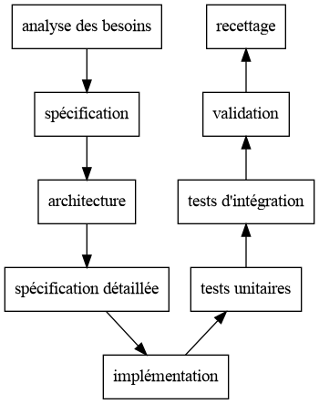

Le modèle était inadéquat non par essence, mais par découpage.

Chacune des cases de chaque colonnes pouvaient être confiées traditionnellement à des équipes « orthogonales » [^9] afin d’éviter que les intervenants dans une étape soit en collusion avec la phase en regard. Et surtout, vous l’aurez notés les codeurs étaient vus comme des ouvriers de gros œuvres, digérant des documents et codant à partir de là.

Le problème est que pour spécifier et estimer la charge, il faut … coder à minima un prototype et que parfois -*horreur*- les défauts de conception en informatique ne se révèle qu’au moment de l’implémentation ou que comme évoqués ci-dessus les standards changent entre la spécification et la livraison.

Alors, les ingénieurs ingénieux ont devisé des « méthodes » pour éviter de faite tout le cycle en V avant de corriger, et de refaire un cycle complet en reroutant les non conformité relevées en remontant les étapes comme un saumon. Genre, si à l’implémentation tu détectes une non conformité tu remontes à la spec détaillée, l’archi … et ainsi de suite jusqu’à la bonne étape avant de faire redescendre les modifications. C’est le fameux modèle en cascade.

Mais c’était toujours chronophage. Surtout dans une industrie informatique qui s’est créée en explosant la muraille de Chine entre MOE/MOA où -*l’absence de responsabilité financière et juridique le permettait*- les équipes en charges de la définition, l’implémentation et la livraison étaient intégrées dans une même entreprise et souvent les mêmes personnes.

## L’avènement de l’organisation « matricielle »

L’organisation matricielle est inspirée de ce qui se fait dans la marine de guerre (où j’ai fait mon service) : quand tu embarques 75 matelots, mais que tu as besoins de 150 équivalents fonction métier alors tu demandes aux matelots d’assurer plusieurs fonctions métiers.

Par exemple, un matelot a d’abord un métier (missilier, bosco, cuistot, fourrier, trans…) mais comme c’est un navire de guerre il est aussi formé à des fonctions généralistes (pompiers, secouristes, quart) il a un poste de combat et peut être appelé à faire des tâches « en dehors de sa fiche de poste ».

Ainsi avec un nombre réduit d’effectifs on peut faire face à plus de charge globale, accroissement de charge qui est déportée sur l’individu.

Ce mode d’organisation qui s’est imposé à l’époque des dot com [^10] a cassé des barrières qui existaient précédemment entre métiers comme le développeur, l’analyste métier, l’assurance qualité.

C’était aussi un peu logique car ils étaient les plus à mêmes de faire ces tâches.

## Les perks des startups

Je dis du mal des *startups*, mais il y avait des moments sympas comme quand Michel Paulin nous expliquait Le business model d’une startup : dégager de l’EBITBA [^11] qui pouvait se résumer selon lui comme suit :

- les CAPEX sont nulles ;
- seules les OPEX comptent

[Le couple OPEX-CAPEX](https://fr.wikipedia.org/wiki/CAPEX_-_OPEX) est important dans la compréhension de la mentalité des dirigeants et donc de leur vision de la notion du métier de l’informaticien.

*En résumé, les investissements (apportés par les investisseurs/emprunts) sont nuls, les dépenses à maîtriser sont les coûts récurrents.*

Ils permettent aussi de décider quand une ressource qui représente un coût récurrent (par exemple … un salarié) est internalisée ou externalisée.

L’investissement dans le cloud plutôt que des infrastructures en propre est guidée par de savants enfumage comptables sur lesquels même wikipedia tique. Mais bon, c’est le domaine non des ingénieurs mais des écoles de commerces, grandes écoles, DAF.

Il est à noter que dans les CAPEX, on compte les rachats des concurrents: ça veut dire que si vous montez votre petite boîte en informatique en profitant des investissements faibles dans ce domaine (quelques serveurs avec la location d’un rack dans un data center coûtent moins chers qu’une voiture) et que vous avez du succès vous avez plus de chances de terminer retraité après le rachat par un grand groupe concurrent (soit pour tuer votre produit, soit pour l’intégrer) que de devenir le big boss d’une entreprise qui sera transmise puisque de toute façon votre concurrence sera les grands groupes qui rachète vos concurrents.

Dans la compréhension OPEX/CAPEX, le coût d’une chose qui peut sembler fixe, genre un serveur engendre des coût opérationnels pendant sa vie : de l’électricité et du réseau à minima, mais aussi le coût des pannes, des remplacements, de l’obsolescence, le temps moyen entre pannes, des mise à jours, des déplacements physiques …. toutes ces choses que l’on regroupe dans le TCO (Total Cost of Ownership).

Vraiment, je m’aventure dans un domaine qui n’est pas le mien, néanmoins, ces notions comptables qui reviennent au moins comme un folklore font parties du décor, comme une musique, une contine.

Bref, si vous entendez ces mots voler autour de vous, sachez que vous êtes dans une *startup* financiarisée à l’anglo saxonne et posez vous la question de savoir si vous êtes du coté des OPEX ou des CAPEX.

Si vous êtes une CAPEX vous êtes utiles que le temps de construire le produit.

Si vous êtes une OPEX vous êtes un coût inutiles qu’il faut réduire.

Si vous entendez CAPEX/OPEX soyez sûr d’avoir des actions (stock options) car de toute façon le but du jeu dans 80% des cas est de devenir en se faisant racheter. Si vous n’en avez pas : lol.

# Risk As A Rent (SaaS/PaaS)

## Avez vous besoin d’un site web ?

Imaginez que vous êtes maraîchers et que vous vouliez développer votre activité sur internet et que vous alliez voir votre banque pour un prêt. Si vous êtes capables d’imaginer ceci, vous êtes capables d’imaginer les logiques derrières les logiques d’internalisation ou d’externalisation des coûts.

Imaginez, toujours que vous êtes férus d’informatique, avez du temps libre en hiver et décidiez de faire VOTRE PROPRE site web de commerce électronique. Même si vous êtes doués vous ne pourrez pas réduire tous les coûts, il va vous falloir des investissements et il va falloir aller à la banque. La banque avant de prêter de l’argent va vous demander :

- combien il vous faut ?
- combien de temps vous estimez qu’il va falloir pour rembourser le prêt au vu des gains que vous allez faire ?
- de combien sont les investissements purs pour finaliser le chantier ?
- de combien sont les coûts opérationnels escomptés ?
- quels sont vos risques et comment les gérez vous ?

Si l’informatique est une activité de création, alors vous êtes face à un problème puisqu’une activité de création est selon toute logique aléatoire, la banque va vous demander non d’être créatifs, mais conservatifs. Ce qui veut dire ; ne pas créer, ne pas prendre de risques, faire comme tout le monde.

Oui mais, je peux m’acheter un rasberry pi, le coller sur ma box et … quoi ?

Tu vas réinventer la cryptographie ? Le paiement en ligne ? le « design » ? Je vous rappelle que vous êtes maraîchers, pas startupeurs avec l’ambition de « disrupter » (perturber) l’ordre établi.

Si vous voulez que la banque vous prête, vous allez d’abord commencer par faire une étude de marché pour vérifier que suffisamment de vos (nouveaux?) clients optent pour l’achat et que c’est un pari rentable et pas trop risqué au vu de votre chiffre d’affaire, et ensuite que les coûts récurrents sont absorbés par le changement de méthode. Est-ce moins cher de vendre par correspondance du frais (qui a besoin d’être livré et l’on retiendra qu’en livraison c’est le dernier kilomètre qui coûte cher), ou de laisser les clients venir à son étal du marché ?

Le coût du changement de votre logistique pour parer à la mise en ligne compte aussi. C’est une chose qu’une société comme amazon a bien compris.

Si vous décidez de vous lancer dans la construction d’un centre de données (Data Center) pour vendre 2 bottes de carottes supplémentaires par mois, vous avez forts à parier que la banque vous prêtera pas d’argent.

Par contre, si vous pouvez appuyer par une étude de marché que rendre vos lieux et heures de présence à tel où tel marché frais augmente votre fréquentation, la banque va vous dire banco … à condition que les investissements puissent être amortis.

Là encore, la banque va tout de suite refroidir vos ardeurs de créateurs si vous voulez vous lancer dans la location d’un rack 1U dans un datacenter et la création d’un site original si vous ne pouvez pas justifier de la plus value de l’investissement.

Vous serez probablement conseillés de faire le « one best way » : faire comme tout le monde et louer votre pelle de chercheur d’or sur internet.

## Le marché des vendeurs de pelle

Pendant la ruée vers l’or, les personnes qui ont gagné le plus de pognons restent les vendeurs de pelle auxquels les chercheurs d’or autant ceux qui devenaient millionnaires que ceux qui ont tout perdu dans l’aventure ont filé leurs caillasses.

En dehors de notre maraîcher, les métiers de l’informatique, découpés en fonction entreprise ont besoin de fond pour développer leur activité, et comme un maraîcher il va être demander aux fonctions métiers de justifier leurs investissements (les fameux capex) au vu des réductions GLOBALES de coûts opérationnels que ceux de l’informatique engendre.

Quoique vous fassiez en informatique, que ce soit du code qui tournerait sans serveur (ex: embarqué) ou de l’infra vous avez des coûts opérationnels. Un logiciel passe la moitié de sa vie en correction, une infra a besoin de bande passante et d’électricité.

Si PHP qui a été de nombreuses fois enterré depuis 1995 est encore là, par exemple, c’est qu’il est derrière pas mal de succès au moins de visites comme facebook, wikipedia, wordpress (l’un des CMS les plus utilisé au monde en mode SaaS), sugarCRM…

## Le marché des pelles qui vous feront pas prendre un rateau

En informatique, il existe une valeur intrinsèque à un logiciel avec une solide base utilisateur : il est dit mûr. Et vouloir construire ce qui a déjà été construit des milliers de fois et qui existe comme un produit fini est voué à l’échec.

Je ne dis pas que je porte wordpress dans mon cœur avec tous ses plugins vérolés qu’un antivax, je dis juste qu’en se restreignant aux plugins de bases et en le mettant à jour il est correque. Si, une association qui a quand même quelques passionnés d’informatique prêts à s’autoformer sur un logiciel je vais leur recommander wordpress, car *chose qui défrise l’agile* : **il y a de la documentation** et ça reste vu son déploiement, il est facile de trouver facilement des péquins pour vous aider sur le sujet, voir même le personnaliser avec du code.

Et comme, quand on conseille un outil, on se trouve parfois lié à sa vie, je conseillerais -*vu qu’il y a des choses qui m’amusent plus que de maintenir un wordpress à jour au vu de la sécurité*- de le prendre en location sur une plateforme qui fait l’hébergement ET les mises à jour. Ce qu’on appelle le SaaS [^12] ou Location de logiciel. Pourquoi ?

Imaginons que je valorise ma main d’œuvre au prix marché soit 490€/jour ; c’est 100 fois le prix d’une location annuelle du logiciel en version basique, 10x la version avec les plugins d’e-commerce intégré.

Si un auditeur comptable descend vérifier les livres d’une entreprise -*que je facturerais pour mes conseils*- il va demander même si je travaille une journée à faire un site statique avec la formation pour sa mise à jour pourquoi on a pas suivi les pratiques du marché ? Serait-ce un abus de bien social qui ne dit pas son nom ?

Vraiment ; pourquoi se faire chier à réinventer la roue carrée quand le marché est déjà inondé de solution de gestion de contenus déjà prête à la location commençant à des tarifs parfois même gratuits ?

## Les dealeurs de logiciel

Selon le code du commerce, la vente à perte est interdite. Dans ce cas, comment peut-on trouver des doses d’informatiques gratuites ?

L’informatique a ceci de magique qu’elle ne semble pas concerner par les lois du commun, étant *-et ce depuis 35 ans-* considérée comme le Far West, qu’il est trop tôt pour réguler. Nulles responsabilités pénales ou financières automatiques (comme dans les autres domaines de l’ingénierie) et même mieux des possibilités de faire des choses que tout autres domaines industriels tenteraient de faire qui verraient entraîner une descente d’inspecteur des impôts et de flics. Genre remettre en cause le monopole régalien d’émission de la monnaie.

L’informatique a ce que l’on appelle une valeur d’externalité : ce qui fait sa valeur n’est pas l’outil, mais la taille du réseau de ses utilisateurs. Un exemple classique est le format de compression. Si ZIP s’est imposé, rar (le format utilisé par winrar) a longtemps réussi à survivre car il avait une forte popularité chez les crackeurs et démo-makers pré internet. Mais il y a aussi gz (unix), 7z, lha …

Ce qui fait qu’un format s’impose, c’est que les gens l’utilisent plus et imposent de fait lors des échanges leur utilisation. C’est comme un format de vis, d’écrou, de tuyau PVC dans la construction.

Il est dès lors de l’avantage des éditeurs de rendre captif le maximum d’utilisateur avec leur première dose le plus tôt possible ; c’est ce qui explique les offres éducation/étudiants préférentielles.

## De la vente de pelle à la location de pelle à la demande 24/7

Vendre des pelles aux chercheurs d’or du numérique, comme des blogs aux influenceurs, des sites de e-commerce, d’e-réputation dont on fait des profits, c’est une chose, mais en 1849 pendant la ruée vers l’or une chose n’avait pas encore été inventée : la pelle comme un service.

T’imagines, même plus besoin d’aller à la quincaillerie du coin acheter ta pelle, ton mulet et ton tamis, ils te sont garantis par contrat être dispo 24h/24, 7j/7 et tu as même plus besoin d’avoir peur que tes outils cassent, en échange de transformer ton achat en location de service. Tu as échangé un coup fixe de 10$ pour une location de 1$/mois avec une SLA 99.999% hourra. Tu y gagnes, pas vrai ? Puis quand t’auras gagné tes premières pépites tu pourras toujours révoquer ton service de pelle pour avoir ton service de pelles internes.

Mieux, tu peux toi même devenir vendeur de pelles numériques grâce à « Platform As A Service », diminuant tes capex et te laissant avec des opex « prévisibles ».

Alors, prévisibles, ça dépend, la jungle des contrats et de leur coût ainsi qu’un modèle basé sur une consommation de ressources qui est non anticipable donne des coûts non anticipables, non ?

Ce modèle de business est celui qui a fait la fortune d’IBM. IBM louait du temps de calcul et vendait ses ordinateurs qui faisait de la containeurisation avant que ce soit hipster. Le cloud et le PaaS sont un resucé du modèle économique du mainframe avec quelques innovations :

- la virtualisation est pilotable logiciellement (donc méchamment automatisable) ;
- grâce à l’informatique on peut générer des factures foutrement illisibles tant elles sont détaillées ;
- comme les conteneurs sont pas vraiment étanches, ils coûtent moins chers.

## Le containeur, une isolation dont les pampers fuitent

Quoi ? Qu’ouïe-je ?

Ben, même si vous avez un bel appel système comme [cgcreate/cgexec](https://labs.iximiuz.com/tutorials/controlling-process-resources-with-cgroups) pour créer des isolations, ou que vous utilisiez les jeux d’instructions [bas niveaux](https://en.wikipedia.org/wiki/X86_virtualization) vous partagez toujours un chassis matériel avec un nombre défini de périphériques.

Aux problèmes anciens de diagnostique applicatif s’ajoute des nouveaux problèmes lié au fait que maintenant il y a plusieurs machines virtuelles qui tentent de taper une ressource unique. Et je vous liste deux des points de douleurs non exhaustifs sur lequel je tombe souvent :

### l’orage des exceptions de pagination de mémoire

Maintenant que vous n’avez une multitude d’applications qui tentent d’accéder à une mémoire centrale, les mécanismes de cache sont plus souvent invalidés, car la régularité émergente d’accès mémoire est remplacé par un accès quasi aléatoire, créant des [orages d’exceptions noyaux](https://en.wikipedia.org/wiki/Page_fault) pouvant ralentir l’accès mémoire d’un facteur 100.

### t’as vu ma montre ?

Les applications modernes distribuées (ab)usent beaucoup de l’horloge haute précision pour mettre des tampons temporels sur leurs messages. Or, même en 2025, cette ressource n’est pas infinie, créant des filles d’attentes sur l’interruption bas niveau. Certes les OS font de leur mieux pour masquer le problème, mais il est souvent vital pour éviter « les messages qui viennent du futur ou qui se collisionnent et pètent le système », que l’heure soit donnée à l’heure.

Il y en a d’autre comme les erreurs 500 liés à l’OOM killer dû au ballonage mémoire la solution consistant à avoir des limites de mémoire fixe et des dimensionnement de RAM en accord avec le profil applicatif, ou encore celui de la « [horde assoiffée](https://en.wikipedia.org/wiki/Thundering_herd_problem) » ….

Les conteneurs hardware et logiciels sont des prisons de verre qui partagent beaucoup de ressources en commun, explicitement comme les interruptions disponibles de timer ou les caches mémoires, ou implicites comme la prédiction de branche hardware qui est à l’origine de nombreux patchs de sécurité.

Un processus, un fil d’execution (thread), un chroot sont eux mêmes déjà des conteneurs, les OS modernes ne font que proposer des conteneurs de diverses tailles et formes qui offrent des gestions diverses des problèmes d’accès concurrents et d’isolation.

Le métier moderne d’informaticien consiste à jouer aux poupées russes en enquillant des conteneurs dans des couches de conteneurs jusqu’à arriver à un processus qui fait tourner le code qu’on livre.

Chaque couche d’abstractions, plus ou moins mûres (kof kof je regarde les couches d’isolation réseaux définies logiciellement particulièrement), apportent leur éventuelles problèmes et bénéfices. Contempler sur windows le nid de pus iptables apporté par un linux tournant en VM/WSL pour apporter les fonctionnalités docker c’est autant contempler l’abîme qu’avoir l’abîme qui vous scrute.

Mais au final, quoique vous fassiez, vous montez du code à une adresse mémoire, et vous pointez le registre PC (program counter) à son origine et vous laissez dérouler au gré des registres de statut …

## Pas CAP d’être ACID

[Le thèorème CAP](https://www.ibm.com/fr-fr/topics/cap-theorem) stipule qu’un système distribué ne peut avoir que deux parmi trois :

- cohérence ;
- disponibilité ;
- tolérance au partitionnement.

Or, pour être ACID comme une base de données relationnelle **intègre** il faut être à minima cohérent, tolérant au partitionnement, et disponible.

Cela veut dire que *quand on a besoin de transactionalité* (c’est à dire que l’on manipule par exemple des factures, ou des identités) il est fortement risqué de mettre ses bases de données transactionnelles dans un système distribué (à la k8s), ou de mettre leur fichiers sur un système de fichier distribué.

Entendez moi bien, je ne dis pas que c’est infaisable et que personne le fait, je dis que l’on introduit un risque **nouveau** qui n’est rarement ni pris en compte, ni évalué en terme de coût de corruption des données. (J’ai vu faire).

Après les gens font ce qu’ils veulent, c’est juste que pour les base de données qui nécessitent de la **transactionalité**, il est chaudement recommandé de ne pas les coller sur un système de fichier distribué.

Alors, oui, on peut avoir un système CAP éventuellement transactionnel, mais ça coûte comme toujours du budget, et je questionne comme d’habitude le fait que le coût du scénario le pire n’est pas calculé, mais accepté. Le scénario le pire est un cas improbable et rare où le système crashe et que l’on ne peut pas restaurer les données.

Et je pense que c’est la transition parfaite avec la partie suivante : ce qui a de la valeur en informatique.

# La donnée et l’information : la dorsale de l’informatique

À peu de choses près on défini la relation entre données et information par :

$$BordelInformationnel=-ln(\frac{donnéesPertinentes}{ensembleDonnées})$$

Ce qui signifie que l’information parfaite c’est quand on présente exactement autant de données pertinentes possibles qu’il y en a de pertinentes de disponibles.

Par exemple, si j’ai une base de données des horaires de toutes les bibliothèques de France, et que vous cherchez l’horaire d’ouverture de LA bibliothèque publique de votre quartier, j’ai le potentiel de vous informer, mais je ne vous informe pas en vous présentant *tous* les horaires, seulement en vous montrant uniquement l’horaire qui vous intéresse.

Vous noterez que google dans sa mouture actuelle fait encore cela très bien.

Jusqu’ici j’ai vaguement traité des outils que l’on appelle « l’informatique » dans l’œil du grand public, les artefacts qui permettent d’avoir l’interface utilisateur pour accéder aux données, et les traiter, je n’ai pas encore parler d’information, et donc d’informatique.

Le principe général de l’informatique est

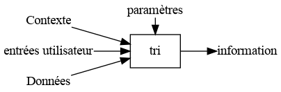

Le contexte est ce qui est implicite, comme par exemple, la localisation géographique de l’utilisateur.

Si je connais la géolocalisation d’un utilisateur et qu’il n’y a qu’une bibliothèque publique dans un rayon de 10 km, je n’ai pas besoin de lui demander de quelle bibliothèque il est question, car implicitement : c’est la plus proche.

Le contexte que nous offre les technologies web permet de trier d’autant mieux l’information pertinente à présenter que l’on a plus de contexte : par exemple, si la langue de présentation de la page web demandée est l’allemand, je vais peut être ajouter la bibliothèque la plus proche proposant des ouvrages en allemand.

Les paramètres c’est ce qui est en contrôle de la boîte de tri et qui correspond à la pertinence du trieur (qui peut être opposée à l’utilisateur).

Par exemple, imaginons que je sois pauvre, et décide pour me détendre de lire « *Ploutos : Dieu du fric* » d’Aristophane, une satire amusante sur la répartition injuste des richesses en ce bas monde.

Mon utilité est maximisée quand je peux lire directement le livre. Or, ça tombe bien, il est dans le domaine public et est disponible sur [gutenberg, un projet qui met à disposition des œuvres du domaine publique](https://gutenberg.org).

Google -*qui est une régie publicitaire*-, amazon -*qui est un vendeur*- n’ont pas « intérêt » à vous montrer en premier cette information quand un de leur client à acheté de la pub/de l’espace pour vendre ce livre.

La notion de pertinence du tri est aussi importante : sachant qu’il n’existe pas de pertinence naturelle, comment les moteurs de recherche ont ils évolué pour être pertinents ?

Et bien avec l’ancêtre de la mécanique utilisée en machine learning : avec des boucles de rétro-action constituées par la présentation de résultats et le clic utilisateur.

Plus l’utilisateur clic dans les premiers choix plus l’information est pertinente. Là encore, le contexte est important : la pertinence pour une recherche va dépendre de qui est l’utilisateur.

On ne montre pas les mêmes produits de beauté selon les genres, les origines, les cultures, l’âge … parce que la beauté est un critère hautement subjectif.

Les données utilisateurs sont au final les « *données non saisies* » nécessaires à trier des informations pertinentes -selon les paramètres de celui qui contrôle le tri- et permettent de définir un prisme de pseudo-pertinence informationnelle.

Je dis pseudo pertinence, car j’insiste : la pertinence absolue n’existe pas ; il n’y a que des prismes déformant selon les paramètres et quelque part dans l’éther absolu de la perfection l’information pure et parfaite non altérée qui est plus ou moins approchée.

## Machine learning

Mais, on peut par contre dégager des consensus de pertinences dès lors que l’on approche la notion de pertinence dans une logique de consensus.

Une manière utilisée pour bâtir le consensus consiste à avoir une armée de petites mains qui se voit présenter aléatoirement des données issues d’une source avec des « étiquettes », de laisser des utilisateurs trier les données par pertinence, et faire apprendre par [machine learning](https://fr.wikipedia.org/wiki/Apprentissage_automatique) à partir de ce classement, et répéter la phase apprentissage jusqu’à obtenir des résultats qui convergent.

Vous allez me dire, avec des 100 aines de milliers de mots dans un dictionnaires, ça va en prendre du temps. Mais bonne nouvelle : on peut automatiser l’apprentissage !

Voici un exemple par méthode fréquentielle d’indexation textuelle :

On peut prendre un texte, le décomposer en vecteur de mots invariabilisés (lemmes). À ces lemmes on peut faire correspondre des lemmes appelées « étiquettes » rattachées au sens que l’on a donné au texte.

Genre, si un texte parle de papa, maman, fifille, on peut le rattacher à « famille », et si en prime ça parle d’aller à la plage on peut rajouter « loisir » et ainsi de suite.

Avec un peu de statistique et de régression on peut déduire d’un texte non étiqueté quels similarités (cosinus) déclenchent le mot clé.

Et ainsi de suite.

Le [Traitement automatique des Langues](https://www.ibm.com/fr-fr/think/topics/natural-language-processing) est un sujet aussi vieux que l’informatique.

À l’aspect « à plat » d’un texte vu comme un vecteur de lemmes, vous pouvez rajouter son aspect séquentiel et établir des probabilité de transitions avec les [chaînes de Markov](https://fr.wikipedia.org/wiki/Cha%C3%AEne_de_Markov) et si vous les combinez vous obtenez … un générateur de langages.

L’IA n’est après ça qu’une question d’avoir accès aux lemmisateurs/tokenisateurs qui pour le français sont des secrets jalousement gardés malgré le fait qu’ils sont élaborés avec de l’argent publique par les universitaires, et d’une phénoménale puissance de calcul pour parcourir l’espace des configurations et déterminer des algorithmes « pas trop faux » en utilisant des boucles de rétro-actions (retour d’expérience) où l’on utilise l’utilisateur des algorithmes pour valider les algorithmes.

En effet, imaginons que vous interagissiez avec un modèle génératif et que vous lui demandez la définition d’un truc, si vous demandez des détails supplémentaires c’est peut être que la définition n’était pas parfaite … et hop, vous faîtes rentrer l’interaction présente dans l’amélioration de l’apprentissage. C’est pour ça que les IA se battent pour que vous les utilisiez, parce que vous êtes de la main d’œuvre gratuite qui améliore l’IA par retours d’expériences programmatique.

## Modifier le prisme de la pertinence

On peut tenter de mesurer avec les algorithmes de NLP la pertinence d’un tri de données en langage naturel, mais on peut aussi volontairement vouloir **modifier** ce prisme, ce qui en langage naturel revient à *changer le sens des mots*.

Genre, je suis roquefort, une nourriture étiquetée E en nutriscore, mais j’aimerais que l’on me voit pas comme un aliment malsain. Comment faire ?

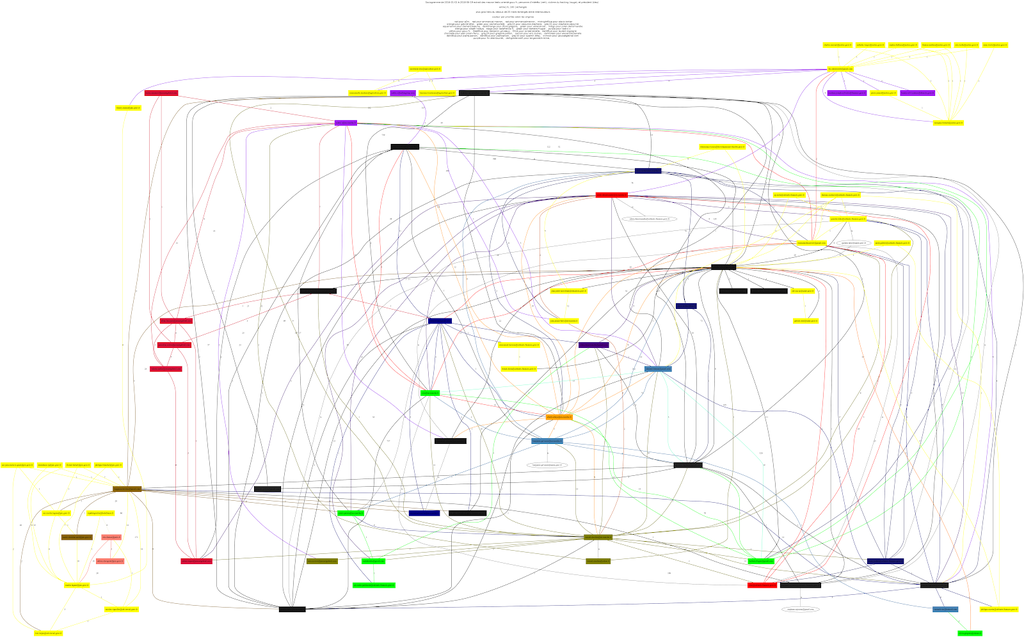

permet de visualiser non plus l’utilisateur, mais l’utilisateur comme des amas d’utilisateurs connectés. Le [chronosociogramme](https://beauty-of-imagination.blogspot.com/2024/04/building-better-chrono-sociogram-radar.html) est plus un outil de visualisation que de modélisation, cependant il permet de comprendre comment on élabore une pertinence « qui s’impose ».

Il suffit de connaître les nœuds les plus connectés et de leur faire émettre le message voulu pour tenter d’avoir une inversion locale de sens.

C’est pas plus compliqué que ça :

- repérer les gens « fameux » ;
- les convaincre de tordre la « vérité » localement ;
- retransmettre le message aux « suiveurs ».

En ceci les réseaux sociaux qui sont basés sur des choix utilisateurs sans « aléas » sont des outils parfaits de modifications de prisme de pertinence informationnelle.

Ne me faîtes pas dire que c’est absolument mal ; l’éducation revient à faire changer le prisme de pertinence, comme par exemple apprendre à mettre un masque FFP3 quand il y a un virus aéroporté qui sévit. Selon que l’on aime ou l’on aime pas cette modification de prisme on appelle ça : *éducation, propagande, publicité, politique, culture*. Juger si la modification de prisme est morale ou pas n’est pas du domaine de l’informatique. Par contre, connaître sa mécanique algorithmique et l’objectiviser est du ressort de l’informatique, parce que cela peut modifier notre quotidien.

Là, le sociogramme inclus plus haut est issu d’un sous ensemble non représentatif de mails issu des « macron-leaks ».

Une campagne électorale est le parangon de l’opération de « changer le prisme de la pertinence ». On y voit les groupes d’influences qui ont été sollicités (sciences po, la mairie de paris, d’obscures entreprises cathos …) ainsi que les acteurs qui sont tous passés de l’anonymat à l’influence politique après la campagne.

Finalement, la question qui se pose concernant l’influence et sa mécanique est que sa mécanique est connue et accessible uniquement par des moyens pécuniers et politiques qui sont accessibles à seulement une partie de la population créant une inégalité dans le processus d’élaboration de « nouvelles pertinences ». C’est pour ça qu’idéalement, j’appelle de mes vœux une [corporation éthique de l’informatique](https://beauty-of-imagination.blogspot.com/2025/02/pour-un-ordre-rene-carmille.html) qui tel l’ordre des médecins veillerait à ce que la société reste mettre de l’**information** telle que définie ici en faisant des informaticiens plus que des employés, mais aussi des garants citoyens et professionnels d’une éthique de l’information (et **des données personnelles**).

# Rester maître de ses compétences

Ce que le monde de l’entreprise fait en morcelant le travail, c’est faire perdre du sens au métier de développeur ; une activité de développeur consistant à réaliser des miettes de développement perd de vue la globalité d’un logiciel.

Parfois, pour se reposer : on part d’un problème, on imagine une solution, on assemble le code nécessaire pour obtenir un résultat, et on livre un logiciel complet, documentation incluse.

## Logiciel libre

Je vous renvoie à [loser du libre](https://jul.github.io/cv/yahi.html) dont le QR code suit pour le développement du chapitre.

[figure not shown]

Loser du libre

Je peux aussi vous renvoyer au manuel de [scam](https://raw.githubusercontent.com/jul/scam/refs/heads/main/assets/aide.book.pdf)

[figure not shown]

manuel de scam

Dans les deux cas, en logiciel libre j’ai pris, deux approches diamétralement opposées, faire tout bien comme un bon élève (yahi) du cycle en V, ou faire tout mal comme un bon salarié qui jette les règles par la fenêtre (scam), c’est à dire en mode agile.

Mais, dans les deux cas, j’ai obtenu un résultat. Et c’est quelque chose que l’on peut faire en logiciel libre : **ce que l’on veut**.

Il est aussi à noter que contrairement au « *logiciel en pièce* » de l’entreprise, en logiciel libre, il est courant qu’un unique contributeur soit à la barre de la spécification, jusqu’à la rédaction de la documentation, et le support (correction de bug, aka support de niveau 3). Ce *« hobby »* permet donc garder une vision en hauteur du métier sur des fonctions normalement distinctes en entreprise : c’est un hobby qui permet de rester maître du code autant que de la méthodologie et d’expérimenter, se faire une expérience concrète.

Ce livre est écrit avec *scam* et c’est très agréable d’avoir un logiciel qui correspond à ses attentes.

Scam qui est lui même la fusion entre un [CRUD HTML as a Model](https://gist.github.com/jul/ca1907d896100ae19dd27e94d2f3a06c) qui a été écrit pour le fun, et un projet précédent d’une [chaîne d’édition markdown](https://github.com/jul/faire_un_livre).

Les projets que l’on fait servent à garder ses compétences, à s’amuser, à explorer, à tester des technologies que l’on utiliserait pas autrement, voir à faire un logiciel que l’on rêve d’avoir.

Ils permettent aussi de questionner le *« one best way »* [^13] si obsédant en entreprise. Par exemple, il est assez poilant de ré-écrire en un minimum de ligne de javascript ce qui est considéré comme nécessitant des milliers de dépendances et un méga framework. On en réalise à quel point le mot « développeur full-stack » quand on lit les compétences demandées est une contradiction dans les termes.

Ces développeurs ont rarement la compréhension de la pile technique qu’ils utilisent et maîtrisent rarement leur pile qui a tendance à se gonfler comme une grenouille qui veut se faire plus grosse que le bœuf, quitte à exploser à la fin.

Je ne suis pas un anti-javascript, c’est un langage amusant, par contre, quand tu dois installer un logiciel déployé à coup de [node](https://nodejs.org/en) et que tu vois des alertes de partout pour raisons de dépendances moisies avec des trous de sécurité, ça refroidit méchamment surtout quand tu sais que tu peux y substituer une centaine de ligne de « vanilla » JS [^14]

Un secret pourtant évangéliser avec forces cris est le plus tu réduis tes dépendances à des frameworks, des librairies, des *middlewares*, le plus tu réduis ta surface de vulnérabilité. Sauf, exception notable quand il s’agit des outils de cryptographie, ce qui inclut : la gestion des mots de passes, des utilisateurs, la gestion des cookies web … là il est fortement conseillé de ne pas réinventer la roue et d’utiliser des logiciels éprouvés pas encore dépréciés. Parce qu’une chose est quasi certaine avec les outils de cryptographie c’est qu’il faut être prêt à les changer. Même si des primitives comme la fonction de hachage MD5 qui est dépréciée depuis que je pratique ou SHA1 se retrouvent encore magiquement dans du code moderne (souvent d’entreprise).

## Autohébergement

De la même manière, même si j’ai arrêté de pratiquer depuis que je ne vis plus avec une IP fixe, héberger ses propres services démystifie les « serveurs ».

La leçon la plus importante que l’on retire, dépend de comment on approche la chose : que ce soit en code ou en administration système j’aime bien le minimalisme, et héberger les services sur la machine la moins puissante de mon « parc ». Mon dernier serveur était un céléron avec 2Gb de mémoire.

Avec ça, on fait tourner sans problème DNS, front web en configuration reverse proxy et serveur dynamique. Nul besoin de sur-qualifier son architecture à la mode *« entreprise »* car le truc qui objectivement sauve vos fesses le mieux est **de bien mettre à jour vos logiciels et de bien les configurer**.

Pour la containerisation j’appréciais la simplicité de mes jails freebsd à contre courant de la mode des infras en mode couche de containeurs sur couche de containeurs : il vaut mieux une architecture simple que l’on maîtrise avec des règles de firewall lisible que des couches de spaghettis de réseaux branlées à coup de logiciels mal (dé)finis.

En 15 ans d’autohébergement, j’ai pas été pwné. Par contre je ne peux pas dire la même chose des entreprises où j’ai traîné qui souvent augmentaient leurs surfaces d’exposition à internet au delà de leurs ressources en administration système.

Être « à la maison » et pouvoir faire comme on l’entend, simplement, est rassurant, faire de ses dix doigts sans se soumettre au marketing constant des nouvelles pratiques a un coté déstressant.

Être sur ses propres serveurs, c’est ne pas avoir besoin de pubs, de traceurs sur ces contenus. Le secret de pouvoir servir moult contenu avec une frêle machine, c’est ce souvenir qu’en qualité de contenu avec son ratio proche d’un caractère significatif par octet servi, le *texte* règne en maître de l’information bien au delà du son et de la vidéo.

Quand on revient en entreprise, avec des sysadmins qui n’ont jamais pratiqué l’autohébergement on s’aperçoit rapidement qu’ils surdimensionnent les architectures ignorant que le graal du 99.999% de SLA est un gouffre budgétaire, et que l’amplement suffisant 99.9% est atteignable avec une pauvre boîte assise dans son coin.

Avoir ses logs permet par ailleurs de voir la constance des menaces venant du vaste monde, qu’elles soient du domaine des attaques non-ciblées (que l’on repère surtout au niveau du serveur SSH et des URLs des serveurs web), ou que ce soit celle tolérées du monde de l’entreprise et de ses pratiques non éthiques comme le scrapping sauvage qui ne respecte pas les *robots.txt* qui a explosé depuis l’avènement de l’Intelligence Artificielle, ou que ce soit le SPAM dans le mail.

C’est cette dernière menace : celle du non respect des règles par les entreprises commerciales qui en volume et en tracasseries représente le plus de menaces de l’auto-hébergement, car il faut, bon gré, mal gré, dimensionner au final ses petites infrastructures pour servir plus de la moitié du trafic en requêtes illégitimes, mais totalement tolérées.

# Tempêtes dans un verre d’eau

J’ai beaucoup marné pour traduire *rant* en français, puis je me suis arrêté à la valeur symbolique que je leur donne : des agitations très localisées qui peuvent paraître violentes, mais qui quand on prend un peu de hauteur restent finalement très circonscrites et pas si importantes.

## YAML c’est bon, c’est fait pour les humains

Alors, non.

À un moment, YAML doit être analysé et la norme qui inclut le templating (gestion de gabarit) fait des centaines de pages. Une telle norme ne peut être qualifiée de simple ni pour l’humain qui doit la décoder visuellement, ni pour celui qui doit en tirer parti quand elle est utilisée à fond les ballons.

Une norme qui n’est pas parfaite mais fait la job, c’est JSON, et même avec des spécifications simples la plupart des analyseurs de JSON ne sont pas compatibles.

Faire une norme interopérable c’est dur.

## L’agile est le cheval de Troie de *« Move fast and break things »*

> Individuals and interactions over processes and tools

> Working software over comprehensive documentation

> Customer collaboration over contract negotiation

> Responding to change over following a plan

L’agile est la toxicité du *«client roi»* de l’hostellerie restauration passée à l’informatique.

Malgré toutes les réticences que l’on peut avoir au modèle en V, le modèle en V s’inscrit dans le cadre de l’ingénierie qui sanctionne de la part des ingénieurs, une responsabilité dans son œuvre mais aussi une capacité d’anticipation qui est liée à un contrat. Contrat qui dicte les fonctions, l’architecture et les unités nécessaires à répondre à un problème précis.

Le défaut du modèle en V tel qu’appliqué à la mode *BTP* dans les années 1990 était d’attendre le recettage avant d’intégrer le client dans les boucles de retours.

Autant il est sain de corriger au plus tôt en collaboration avec le client (ce qui est l’adage du manifeste que je garde), autant, le contrat et ses documentations (qui permettent de faire les tests unitaires et fonctionnels) sont la seule manière d’avancer sans casser l’œuvre en même temps qu’on avance vite.

Je dirais même que pour modifier rapidement et garder la confiance du client, il faut avoir des tests et donc des documentations (architecture, specs techniques et fonctionnelles) au plus tôt.

Et un contrat protège : autant le client des malfaçons (architecture bling bling qui tient pas la charge et explose les investissements et coûts opérationnels), que le salarié qui se retrouve dans une logique d’arbitraire où l’esprit de la meute insufflé par les standups remplacent les discussions parfois nécessaires et souvent plus fructifère entre fonctions bien identifiées de mano à mano.

## Cléricalisme : le vent d’OAuthan rend fou

Quand je vois un gars pas mauvais dire que juste la norme oauth est imbitable (voir la tempête sur YAML) comme illustré ci dessous.

[figure not shown]

Matthew Green parle de OAuth

J’ai envie de dire que j’ai pas besoin de fulminer : il l’a déjà fait pour moi.

Par contre c’est l’arbre qui cache la forêt de la mentalité cybersécurité. Prendre pour profond ce qui est obscur.

En tant qu’implémenteur, développeur, je me trouve du coté du bâton de merde de la norme, et il m’arrive plus souvent que jamais de me voir imposer des normes par des architectes, spécialistes de la cybersécurité qui ne lisent pas les normes qu’ils poussent par effet de foule plus que par réflexion personnelle.

Et les échecs ne sont jamais de leurs cotés de clergé de la Sécurité, mais du coté du code.

Quand on m’impose une norme qui est aussi complexe qu’openID, OAuth, SAML, il serait bien en tant que développeur, pour ne pas faire de conneries que le chemin dans le champs de mines soit balisé avec des parcours utilisateurs/des configurations déjà réfléchies. Mais, ce n’est jamais le cas.

Le clergé règne sur le monde séculaire, mais refuse de se mêler des problèmes temporels.

# IAM SSO AAA ! Les 3 cavaliers de l’apocalypse

IAM, AAA et SSO sont les 3 cavaliers de l’apocalypse qui font que la user story la plus basique : faire un formulaire web pour remplir un couple identifiant, mot de passe puisse devenir un cauchemar.

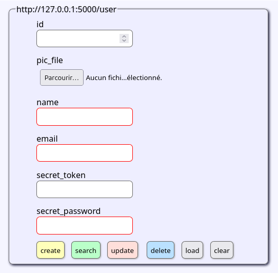

Formulaire de gestion d’utilisateur

J’ai pourtant assisté à moult cérémonies agiles où cette histoire utilisateur était qualifiée comme la moins compliquée.

Il n’y a pas de possibilité de créer ce formulaire sans qu’avant préexistent :

- *AAA* (Authentication Authorization Accounting) : gérer la reconnaissance du mot de passe, les droits, et suivre à la trace les actions utilisateurs
- *IAM* (Identity Access Management) : comment les utilisateurs vont être gérés ;
- *SSO* (Single Sign On) : la persistance de la sécurisation surtout quand on est dans un contexte *stateless* (connexion sans état, comme http) ;

## AAA

Le premier A de AAA est l’art de penser au parcours de mot de passe et sa récupération. Pourquoi, parce qu’un utilisateur, soit oubli son mot de passe, soit disparaît (souvent d’une entreprise, hein ?). C’est l’Authentification, s’assurer que la personne est qui elle prétend être. C’est un problème (non) résolu dans sa version la plus simple depuis longtemps : on demande une première fois à l’utilisateur son mot de passe, on stocke un hachage du mot de passe (et non le mot de passe en clair) et par la suite, on compare le hachage rentré avec celui stocké. Ça évite aussi les vols de mots de passe. Seul problème, depuis un hachage on peut soit par force brute, soit par défaut de collision dans la fonction (défaut qui finit par être trouvé tôt ou tard) trouver le mot de passe. Bonne nouvelle, la force brute a un coût (certes potentiellement amortissable), ces fonctions sont préférablement changeable.

Le deuxième A est l’Autorisation : définir la politique d’accès aux ressources. En général, ça tombe pas du ciel, mais en général aussi, c’est rarement spécifié, surtout dans les users stories modernes alors que ça change radicalement le modèle de données.

Le troisième A est l’Accounting (le service compta vous épie) : souvent, derrière une ressource, il y a du pognon impliqué. Si il n’y a ni dépense ni recette, c’est pas une ressource que vous avez mis en base, mais du vent. Passons : l’accounting consiste à tracer qui a fait quoi quand. Aussi bien pour la comptabilité, que pour un éventuel post mortem de sécurité. En général, c’est là où les journaux loin des bases sur lesquelles les utilisateurs ont les droits sont de mises.

L’AAA, c’est le B.A-B-A et pourtant tarte à la crème oblige c’est un désert de solitude pour les codeurs qui doivent le pratiquer.

Il n’y a pas de framework AAA, c’est plus une manière de systématiser la pensée autour de la sécurité des données et de poser les bonnes questions, proposer/préparer des solutions en fonction de la portée du problème.

Par exemple, si vous faîtes un jeu casuel, vous avez plus intérêts à tenter de convaincre les proches du joueur de jouer pour augmenter la valeur de réseau, et donc vous serez tentés d’utiliser une authentification fournie par un réseau social tiers. Par contre, surtout si vous avez des micro transactions liées au compte, vous allez vouloir faire l’autorisation et l’accounting à la maison.

## SSO

Authentifié une fois, prêt à rentrer partout où l’on a les droits. Comme si quand on ouvrait la porte d’un bureau physique, tous les meubles fermés à clé s’y trouvant se déverrouillaient magiquement.

# Les maquignons de l’informatique

Et si au lieu de voir les informaticiens comme des cols blancs on les regardait comme de vulgaires ouvriers balladés de chantier en chantier par des maquignons qui leur volent primes et salaires différés avec la complicité d’hommes politiques complices ?

Mais pour qu’il y ait maquignonage il faudrait qu’il y ait un cartel de prix, et ce serait et crier à la conspiration et à la corruption.

D’abord établissons en quoi l’informaticien est victime de pratique de maquignonage.

Pour ça il faut b(i)aiser au moins un parmi : l’offre et de la demande. Là c’est bon, les maquignons tiennent les deux bouts.

## Comment le maquignon influence son client : la bataille des OPEX

Je vous renvoie au chapitre concernant les opexs, les capex et les logiques d’outsourcing.

Je vais résumé ici le concept comptable qui permet aux maquignons de s’imposer par analyse comptable des valeurs métiers.

Les ressources humaines ont un coût. Plus le flux de travailleurs est élevé (churn), plus ce coût est élevé et on peut soit vouloir diminuer les coûts de RHs en contournant la loi, soit internaliser la fonction car on juge que mener à un bien des chantiers nécessite de bons ouvriers (compétents car ils coûtent chers).

La gestion RH est externalisable. Et il est tentant alors que moult projets informatiques sont « contruits » avant d’être maintenu en condition opérationnelle (ce qui nécessite d’autres compétences) d’éviter de payer les dûs comme les primes de chantier (CDI C) ou les primes de précarités (CDD) pour les ouvriers bâtisseurs. Mais une fois que le projet est fini, basta les ouvriers. Comment se fait-il que sur les panneaux d’affichage des offres d’emploi il y ait au final si peu de CDD, CDI-C ?

C’est une question que vous vous êtes jamais posée car on vous a élevé au fouet de la bonne position c’est celle avec un CDI ?

Et peut être même que ce bourrage de mou est dû à votre employeur le maquignon qui vous a vendu un CDI pour vous ballader de chantier en chantier de fait qui seraient mieux qualifiés en CDD ou CDI-C.

Peut être que le business model de votre employeur est de vendre l’amortissement comptable entre payer des CDI-C et des CDD et embaucher des ouvriers bâtisseurs en CDI et les placer en mission chez le client ?

Vous allez me dire, c’est dans l’intérêt du client d’éviter de payer 10% en plus de salaires. Mais pourquoi alors payent-ils 5 fois le prix de la ressource pour économiser 10% de 100 ?

Et bien, mes amis … roulement de tambour … parce l’externalisation de la fonction RH ne marche que dans l’hypothèse d’une concurrence non faussée, dont malheureusement le crime paie, car les boîtes ont une boucle de rétroaction positive qui amplifie sa vulnérabilité aux maquignons : les short lists.

À partir du moment où tu externalises ta fonction RH, tu gardes le strict minimum de RH (celui qui signe le chèque pour le patron et les vrais cadres qui encadrent).

Et pour les cols bleus dont tu as besoin à la pelle (sinon ton externalisation, c’est bidon), tu réduits forcément tes listes de fournisseurs.

Fournisseurs dont le business model est de satistfaire suffisamment avec des perks comptablement assumés la satisfaction travailleurs avec du café et du baby gratuit, et des beuveries hors temps de travail qu’en assummant l’intercontrat sur leur fond propres, elles permettent aux clients finaux d’économiser sur des factures des primes de précarité liés à la nature finie d’un chantier.

Oui, je vous entends hurler que ça vous va très bien, mais imaginez que sur un marché, il n’y a pas que les fans de CDI à tout prix qui ont le droit d’exister.

On est une minorité, sûrement, de mercenaires qui préférerions des contrats précaires avec les clients finaux et gagner plus, plutôt que de passer par les maquignons.

Pourquoi, parce qu’on aimerait bien être payer 10% de plus a minima, voire probablement plus si le marché était rationnel.

C’est toute la logique de pas voir un budget chantier exploser : des gens qui en contrepartie de s’engager à livrer en temps donné son raccord avec le fait que quand c’est fini c’est fini, et quand c’est fini ils partent avec une prime.

Maintenant, vous avez sur votre short list des maquignons qui n’ont pas intérêt à ce que vous fassiez le choix logique, mais le choix qui ont intérêt à faire une cabale pour vous vendre des projets jamais finis.

L’agile est une méthode de lavage de cerveau vendue au client pour ne plus exiger que les chantiers se terminent.

Le maquignon non seulement vous impose ses prix, mes aussi les méthodlogies qui redéfinissent les contrats de chantiers qui normalement ont une fin, et une chaîne de tâches infinies dont on ne documente plus les documents comptables nécessaires à déterminer ce qui est un livrable.

Lentement, les clients se font empoisonner avec des chevaux de Troie qui refourguent non seulement des biaiseurs de prix, mais aussi des pratiques contournant joyeusement les principes de la comptabilité qui exigent que pour une facture on puisse juger sur pièce de la réalité de la chose achetée.

## Si c’était un trou de sécurité informatique, on appellerait ça un DDOS par effet de levier.

La fonction RH des entreprises, externalisée avec une short list, donne un bras de levier aux plus gros du marché de la « CDI-sation » des « CDDs », en leur offrant en plus une place de choix pour aider à recommander dans la fonction RH de l’entreprise de prise de décision, de les choisir eux plutôt que des ouvriers de chantiers.

Le maquignon est juge et partie dans la fonction RH cliente.

## Comment le maquignon influence l’offre : la bataille du BS

À coup de légende urbaine, de bouche à oreille, de pratiques déloyales, de croyance dans le fait que c’est malheureusement la seule voie.

C’est quoi l’alternative ?

Un des alternatives, et je ne juge pas est le graaal : être placé en CDI pour un chantier qui a une fin en espérant que le client ait suffisamment de chantiers pour assurer de rester en activité à durée indéterminée.

Tiens, prends une agence de pub qui fait des sites concours pour des marques.

Ils enchaînent bien les chantiers en masse, toujours pareil, toujours différents.

Où les jeux, chaques jeux est un immense chantier qui nécessitent des compétences rares, c’est dans l’intérêt des auteurs de jeux AAA de fidéliser leurs ouvriers en leur proposant des CDI à la place des CDDs.

En plus pour obtenir des crédits et pouvoir avoir une vie normale rien ne vaut un CDI.

Néanmoins, la réalité client reste. Les pipelines de productions ne sont pas linéairement continus, et la main d’œuvre désœuvrée coûte chère. Donc, quand la disette arrive l’employé CDI-sé pour lequel la rupture de contrat coûte plus cher que l’employé de CDD des techniques sans coût comptables RH existent. Harcèlement, placardisation, incitation à la rupture conventionnelle par pression sociale …

Et si une chose est garantie dans le capacity planning c’est l’irrégularité des pipelines de production.

Donc le graal est rarement le maquignon qui a les raisons économiques et la spécialisation RH nécessaires à faire des CDDs déguisés en CDI, incluant les coût/coups bas dans les tibias.

Mais si vous faîtes de la recherche d’emploi, vous constatez que la même offre apparaît souvent :

> Pour le compte d’un client nous recherchons un profil …

qui laissent miroiter que le maquignon en plus de son troupeau de CDD-CDIsés a une activité de placement.

Évidemment, à chaque fois que vous allez commencer à devenir sérieux, vous allez découvrir que la mission a disparu, a déjà été remplie ….

Dans le meilleur des cas pour le maquignon, si il vous embauche il retient en otage la ressource que le client veux, et peut soit la négocier plus cher à l’embauche (en se faisant une petite prime au passage), soit en la monneyant plus chère à la location.

Vous allez me dire selon le vieil adage de droit romain « nul ne peut se prévaloir de ses propres turpitudes » ce business de filou ne pourrait exister, car la loi c’est la réalité, et la loi interdit ce genre de pratique que s’appellerio délit de marchandage. Sauf, que ce délit ne semble pas s’appliquer aux employés en informatique. La cour de cassation, les juridictions prud’hommal s’en contre care du délit de marchandage quand ça s’applique au domaine de l’informatique.

C’est même rigolo, car tu vois pourtant des métiers intellectuels dans les arrêts de la cour de cass, qui sanctionnent les entreprises en faveurs des salariés en requalifiant des presta. externes en CDD quand elles sont une concurrence déloyale au salarié interne, histoire de décourager la pratique.

Corruption ? Conspiration ?

## Les conspirations existent-elles ?

Il y a t’il réellement des cas prouvés de gens qui se réunissent dans le secret pour nuire à la majorité ?

Et bien oui, ça s’appelle des cartels de prix, et vu ce que la juridiction européenne passe son temps à aligner à coup de prunes et de jugement on peut dire que localement, la pratique des conspirations est un fait étayé et prouvé.

Quand il s’agit de fausser les marchés libéraux, la conspiration est avérée et répandue.

Accuser les maquignons de conspirer contre l’offre (les clients) et la demande (les développeurs) n’est pas capillotracté.

D’ailleurs, quand on voit des anciens membres de parlement influents qui ont lutté contre l’application du délit de marchandage pantoufler chez des maquignons, on peut trouver cela suspicieux comme un renvoi d’ascenseur.

Ce que l’on appelle la tech c’est avant tout un gigantesque marché du maquignonage qui coûte par ses pratiques déloyales autant aux clients, qu’aux dévs, qu’aux caisses sociales.

Ces acteurs déloyaux sont un frein à la concurrence loyale entre travailleurs et leur viande qu’ils survendent et exploitent en ne versant pas la juste rétribution qui leur est dû. On connaît tous les quidams payés 100€/jours revendus expert à 1000€/jour chez le client, le maquignon embauchant royalement la différence de x9 au prétexte d’amortir un risque d’intercontrat de 5%.

Bordel, ni le client, ni le dev, ni les caisses sociales sensées touchées leur juste part des salaires n’y gagnent.

C’est de l’abus de bien social, de la distorsion de concurrence, un business illégal, qui n’a pas lieu d’exister, mais qui existe car la loi n’est pas réalité par la grâce de la complicité de nos députés.

[^1]: opérateurs télécoms et réseaux dans le jargon telco
[^2]: business hour en français de Paris
[^3]: Ressources Humaines
[^4]: appelés **charges salariales** par les patrons
[^5]: handover en français de Paris
[^6]: Recherche et Développement
[^7]: contrairement à mon emploi du temps passé le projet existe encore et vit toujours, hein ?! Mais c’est plus la « hype » que c’était.
[^8]: Vautour Capitaliste parfois appelé investisseurs capital risque
[^9]: Ce que l’on appelait la muraille de Chine
[^10]: autrement appelées startups a décloisonné les métiers de l’informatique. Les informaticiens qui codaient se sont aussi vus confiés l’avant vente (rédaction des spécifications techniques), la rédaction des tests unitaires, la correction de leurs bugs.
[^11]: indicateur financier américain qui signifie “Earnings Before Interest, Taxes, Depreciation, and Amortization”
[^12]: Software as a Service
[^13]: **la** bonne manière de faire
[^14]: vanilla JS : petit nom donné au javascript utilisé sans librairies ni dépendances. Le javascript dans sa saveur la plus basique.